# IODS course project

# Chapter 3 – Logistic regression

```
## [1] "Fri Dec 04 03:13:34 2020"
```

## 3.1 Data wrangling

On this part: - merge downloaded datasets and keep students existing both datasets - define high alcohol consumption

Data source: https://archive.ics.uci.edu/ml/datasets/Student+Performance

Here is code:

```r
# Attach library
library(dplyr)

# Change working directory
setwd("~/kursusIODS2020/IODS-project")

# Read 2 datasets from .csv to R
math = read.csv(file = (paste0(getwd(), "/Data/student-mat.csv")), sep=";")
por = read.csv(file = (paste0(getwd(), "/Data/student-por.csv")), sep=";")

dim(math)  # check data
dim(por)
str(math)
str(por)

# Merge datasets

# Common columns to use as identifiers
join_by = c("school","sex","age","address","famsize","Pstatus", "Medu",
             "Fedu","Mjob","Fjob","reason","nursery","internet")

# Join the two datasets by the selected identifiers,
# keep rows existing in both table
math_por <- inner_join(math, por, by = join_by,
                       suffix = c(".math", ".por"))
# Check new datafile
dim(math_por)
glimpse(math_por)


# Next part will combine two possibly different
# answers to the same questions for each student -
# combine these 'duplicated' answers by taking mean/first answer

# Create a new data frame with only the joined columns
alc <- select(math_por, one_of(join_by))

# The columns in the datasets which were not used for joining the data
notjoined_columns <- colnames(math)[!colnames(math) %in% join_by]

# Print out the columns not used for joining
notjoined_columns

# For every column name not used for joining...
for(column_name in notjoined_columns) {
  # select two columns from 'math_por' with the same original name
  two_columns <- select(math_por, starts_with(column_name))
  # select the first column vector of those two columns
  first_column <- select(two_columns, 1)[[1]]
  # if that first column vector is numeric...
  if(is.numeric(first_column)) {
    # take a rounded average of each row of the two columns and
    # add the resulting vector to the alc data frame
    alc[column_name] <- round(rowMeans(two_columns))
  } else { # else if it's not numeric...
    # add the first column vector to the alc data frame
    alc[column_name] <- first_column
  }
}

# glimpse at the new combined data
glimpse(alc)


# Create new columns -
# - alc_use --  average of weekday and weekend alcohol consumption
# - high_use -- logical if average consumption is more than 2 units

alc <- mutate(alc, alc_use = (Dalc + Walc) / 2)
alc <- mutate(alc, high_use = alc_use > 2)

dim(alc)
# [1] 382  35
str(alc)

# Write data file to locak folder as .csv file
write.csv(alc, file = (paste0(getwd(), "/data/alc.csv")), row.names=F)
```

## 3.2 Logistic regression analysis

Today’s libraries:

```r
library(dplyr); library(tidyr); library(ggplot2); library(Epi)
```

### 3.2.2 Read data

As the result of data merging is not complete there (Reijo’s e-mail) and my time has limits, so I cheat and read data from web:

```r
alc = read.csv(file = "https://github.com/rsund/IODS-project/raw/master/data/alc.csv", sep=",")

dim(alc)
```

```
## [1] 370  51
```

```r
names(alc)
```

```
##  [1] "school"     "sex"        "age"        "address"    "famsize"
##  [6] "Pstatus"    "Medu"       "Fedu"       "Mjob"       "Fjob"
## [11] "reason"     "guardian"   "traveltime" "studytime"  "schoolsup"
## [16] "famsup"     "activities" "nursery"    "higher"     "internet"
## [21] "romantic"   "famrel"     "freetime"   "goout"      "Dalc"
## [26] "Walc"       "health"     "n"          "id.p"       "id.m"
## [31] "failures"   "paid"       "absences"   "G1"         "G2"
## [36] "G3"         "failures.p" "paid.p"     "absences.p" "G1.p"
## [41] "G2.p"       "G3.p"       "failures.m" "paid.m"     "absences.m"
## [46] "G1.m"       "G2.m"       "G3.m"       "alc_use"    "high_use"
## [51] "cid"
```

Data consists information about 370 students.

This data approach student achievement in secondary education of two Portuguese schools. The data attributes include student grades, demographic, social and school related features) and it was collected by using school reports and questionnaires. Two datasets are provided regarding the performance in two distinct subjects: Mathematics (mat) and Portuguese language (por). Purpose is to find model to describe high alcohol consumption.

Complete data description is on this link https://archive.ics.uci.edu/ml/datasets/Student+Performance

### 3.2.3 Variables selection, hypotheses

I selected out variables significantly related with high alcohol consumption.

- *absences* – number of school absences (numeric: from 0 to 93)
- *studytime* – weekly study time (numeric: 1 - <2 hours, 2 - 2 to 5 hours, 3 - 5 to 10 hours, or 4 - >10 hours)
- *reason* – reason to choose this school (nominal: close to ‘home’, school ‘reputation’, ‘course’ preference or ‘other’)
- *sex* – student’s sex - male (M), female (F)

I assume that:

- absences are related with higher alcohol consumption
- longer study time is related with lower probability of high alcohol consumption
- the high alcohol consumption is more reare among these who selected school by reputation and/or course selection compared to home and/or other selection reason
- male students have more frequently high alcohol consumption.

### 3.2.4 Variables and alcohol consumption

We have 111 students with high and 259 low alcohol consumption.

```r
table(alc$high_use)
```

```
##
## FALSE  TRUE
##   259   111
```

**Sex** is significantly related with alcohol consumption p<0.001 (Chi-square test). 40% of males and 21% of females have high alcohol consumption.

```r
pctab(table(alc$sex, alc$high_use), dec=1)
```

```
##
##     FALSE TRUE All   N
##   F    79   21 100 195
##   M    60   40 100 175
```

```r
chisq.test(alc$high_use, alc$sex)$p.value
```

```
## [1] 0.0001120883
```

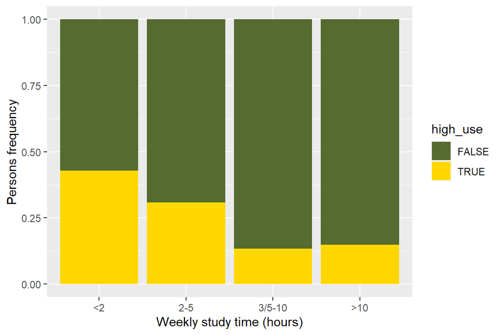

```r
ggplot(data = alc, aes(x = as.factor(studytime), fill = high_use)) +
  geom_bar(position = "fill") +
  scale_fill_manual(values = c("darkolivegreen", "gold")) +
  scale_x_discrete(name = "Weekly study time (hours)",
                  labels = c("<2", "2-5", "3/5-10" ,">10") ) +
  scale_y_continuous(name = "Persons frequency")
```

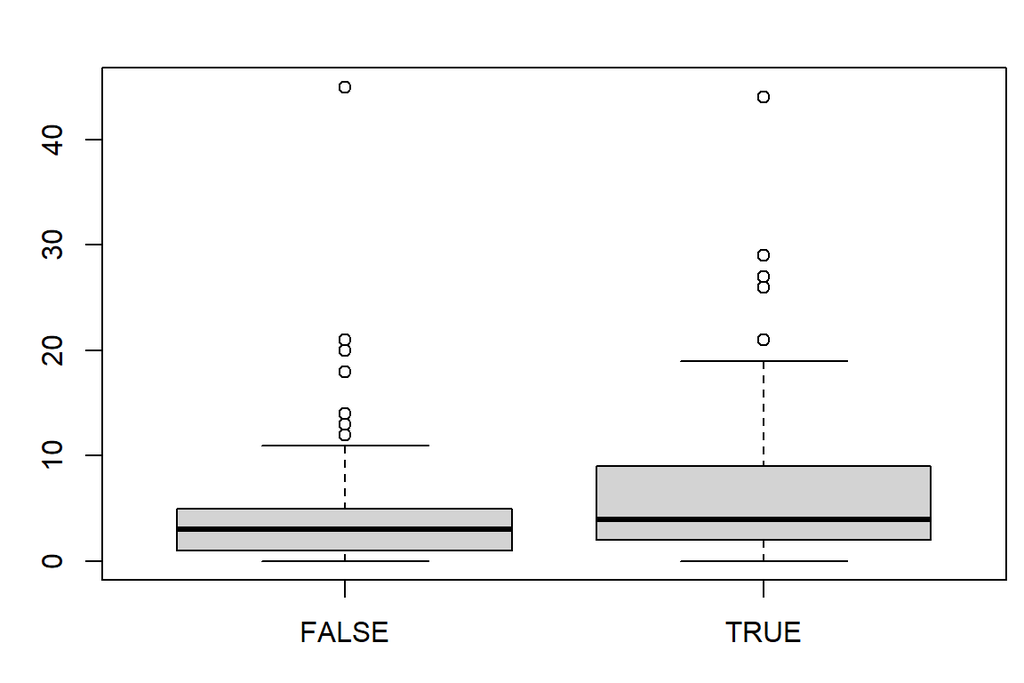

```r
par(mai=c(0.6, 0.6, 0.4, 0.1), cex=1)
boxplot(alc$absences ~ alc$high_use, ylab="No of absences", xlab="High alcohol consumption")
```

**Reason to choose school** is related with high alcohol consumption (p=0.0226704).

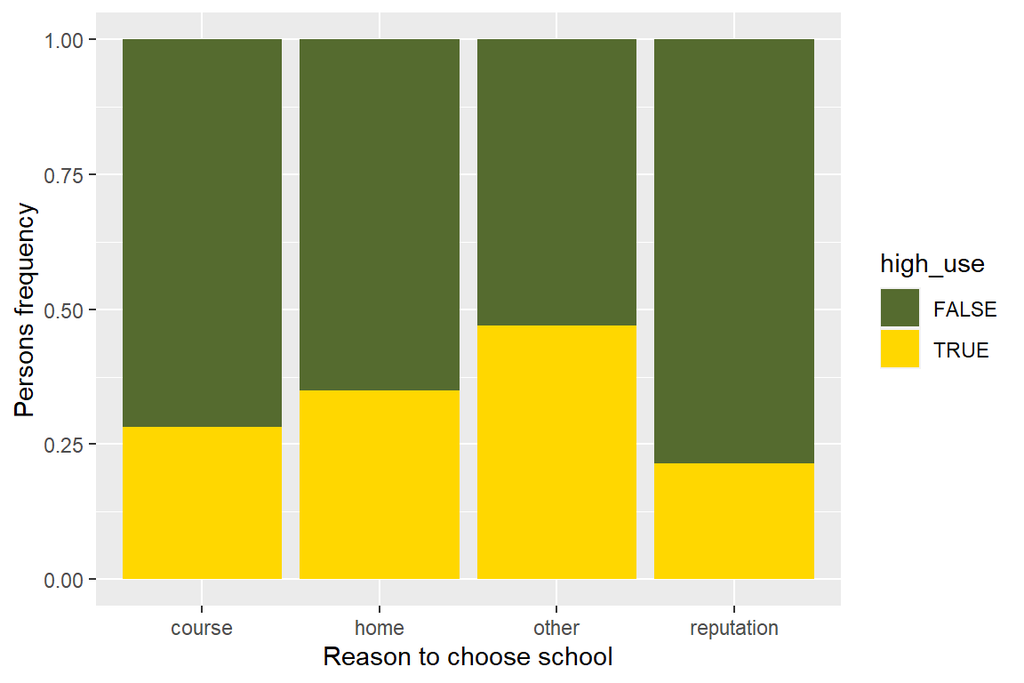

```r
ggplot(data = alc, aes(x = reason, fill = high_use)) +
  geom_bar(position = "fill") +
  scale_fill_manual(values = c("darkolivegreen", "gold")) +
  scale_x_discrete(name = "Reason to choose school") +
  scale_y_continuous(name = "Persons frequency")
```

All my hypotheses are fine.

### 3.2.5 The model

Nice function for better logistic regression output reading

```r
expcoef = function(model)           {
  coeffs <- coef(summary(model))
      or <- exp(coeffs[ ,1])
     lci <- exp(coeffs[ ,1] - 1.96 * coeffs[ ,2])
     uci <- exp(coeffs[ ,1] + 1.96 * coeffs[ ,2])
       p <- round(coeffs[ ,4], 5)
 expcoef <- cbind("OR"=round(or,2),
                  "lci"=round(lci,2),
                  "uci"=round(uci,2), p)
  expcoef
}
```

Estimate logistic regression model and see the output

```r
m <- glm(high_use ~ relevel(as.factor(studytime), 3) + absences +
           relevel(as.factor(reason), "reputation") +  sex, data = alc, family = "binomial")

expcoef(m)
```

```
##                                                  OR  lci  uci       p
## (Intercept)                                    0.06 0.02 0.16 0.00000
## relevel(as.factor(studytime), 3)1              2.62 1.06 6.46 0.03613
## relevel(as.factor(studytime), 3)2              2.22 0.96 5.14 0.06206
## relevel(as.factor(studytime), 3)4              1.15 0.30 4.38 0.83580
## absences                                       1.09 1.04 1.15 0.00018
## relevel(as.factor(reason), "reputation")course 1.43 0.74 2.77 0.28976
## relevel(as.factor(reason), "reputation")home   1.50 0.76 2.95 0.24451
## relevel(as.factor(reason), "reputation")other  3.12 1.26 7.73 0.01372
## sexM                                           2.36 1.41 3.94 0.00104
```

Adjusted model reveals:

### 3.2.6 Predictions

Add the predicted probabilities to ‘alc’ and make a prediction of high_use (probablities>0.5)

```r
alc <- mutate(alc, probability = predict(m, type = "response"))
alc <- mutate(alc, prediction = probability>0.5)
```

Function that gives target variable versus the predictions, prediction cut-off value is changeable:

```r
confusion = function(ref) {
  table(high_use = alc$high_use, prediction = alc$probability>ref)}
```

Confusion matrix (the target variable versus the predictions) and relative frequencies:

```r
confusion(0.5)
```

```
##         prediction
## high_use FALSE TRUE
##    FALSE   247   12
##    TRUE     80   31
```

```r
confusion(0.5) %>% prop.table %>% addmargins
```

```
##         prediction
## high_use      FALSE       TRUE        Sum
##    FALSE 0.66756757 0.03243243 0.70000000
##    TRUE  0.21621622 0.08378378 0.30000000
##    Sum   0.88378378 0.11621622 1.00000000
```

Calculate relative frequency of incorrect predictions

```r
sum(confusion(0.5)[1,2], confusion(0.5)[2,1])/sum(confusion(0.5))
```

```
## [1] 0.2486486
```

The 66.8% of sample is correctly predicted to low-alcohol group and 8.4% is correctly defined as high-alcohol group. Totally wrong predictions had 24.9% of sample.

Simple testing:

Prediction cut-off point 0 should give all predictions as high-alcohol

```r
confusion(0)
```

```
##         prediction
## high_use TRUE
##    FALSE  259
##    TRUE   111
```

and prediction cut-off point 1 should give all low-alcohol predictions

```r
confusion(1)
```

```
##         prediction
## high_use FALSE
##    FALSE   259
##    TRUE    111
```

It seems working!

Really sorry - no time for bonus exercises on this time. I worked cross-validation throw from DataCamp and I found it useful.

# Chapter 4 – Clustering and classification

```
## [1] "Fri Dec 04 03:13:38 2020"
```

## 4.1 Data wrangling for chapter 5

### 4.1.2 Read the data

Read the “Human development” and “Gender inequality” datas into R.

Meta file and some technical notes:

http://hdr.undp.org/en/content/human-development-index-hdi http://hdr.undp.org/sites/default/files/hdr2015_technical_notes.pdf

```r
hd <- read.csv("http://s3.amazonaws.com/assets.datacamp.com/production/course_2218/datasets/human_development.csv", stringsAsFactors = F)
ii <- read.csv("http://s3.amazonaws.com/assets.datacamp.com/production/course_2218/datasets/gender_inequality.csv", stringsAsFactors = F, na.strings = "..")
```

### 4.1.3 Explore the datasets

```r
dim(hd); dim(ii)

names(hd)
names(ii)

summary(hd)
summary(ii)
```

### 4.1.4 Rename variables

```r
names(hd) = c("hdi.rank", "country", "hdi", "life.exp.birth", "exp.educ", "mean.educ", "gni", "gni.minus.hdi")

names(ii) = c("gii.rank", "country", "gii", "maternal.mort.ratio", "adoles.birth.rate", "parliament" ,"sec.edu.f", "sec.edu.m", "labour.rate.f", "labour.rate.m"  )
```

### 4.1.5 Add variables

Add to “Gender inequality” ratio of female and male populations:

- secondary education in each country
- labour force participation

```r
library(dplyr)
ii = mutate(ii, edu.ratio = sec.edu.f/sec.edu.m)
ii = mutate(ii, lab.ratio = labour.rate.f/labour.rate.m)
# First rows of mutated dataset
head(ii, n=3)
```

### 4.1.6 Merge datasets

```r
human <- inner_join(hd, ii, by = "country")

names(human)
dim(human)

# Write data to file
write.csv(human, file = (paste0(getwd(), "/data/human.csv")), row.names=F)
```

## 4.2 Data analysis

```r
# Do some cleaning work
rm(list = ls())

# Todays libraries:
library(MASS); library(corrplot); library(tidyverse)
```

### 4.2.2 Load and describe Boston data

Load and explore the dataset Boston (offered in library MASS).

```r
data("Boston")
str(Boston)
```

Boston dataset contains information collected by the U.S Census Service concerning housing in the area of Boston Mass. Dataset has 506 rows and 14 variables. All variables, except binary *chas*, are numberic. See descriptive statistics on next chapter.

| variables | explanation |
| --- | --- |
| crim | per capita crime rate by town. |
| zn | proportion of residential land zoned for lots over 25,000 sq.ft. |
| indus | proportion of non-retail business acres per town. |
| chas | Charles River dummy variable (= 1 if tract bounds river; 0 otherwise). |
| nox | nitrogen oxides concentration (parts per 10 million). |
| rm | average number of rooms per dwelling. |
| age | proportion of owner-occupied units built prior to 1940. |
| dis | weighted mean of distances to five Boston employment centres. |
| rad | index of accessibility to radial highways. |
| tax | full-value property-tax rate per $10,000. |
| ptratio | pupil-teacher ratio by town. |
| black | 1000(Bk - 0.63)^2 where Bk is the proportion of blacks by town. |
| lstat | lower status of the population (percent). |
| medv | median value of owner-occupied homes in $1000s. |

### 4.2.3 Overview of the data

Descriptive statistics:

```r
summary(Boston)
```

```
##       crim                zn             indus            chas
##  Min.   : 0.00632   Min.   :  0.00   Min.   : 0.46   Min.   :0.00000
##  1st Qu.: 0.08205   1st Qu.:  0.00   1st Qu.: 5.19   1st Qu.:0.00000
##  Median : 0.25651   Median :  0.00   Median : 9.69   Median :0.00000
##  Mean   : 3.61352   Mean   : 11.36   Mean   :11.14   Mean   :0.06917
##  3rd Qu.: 3.67708   3rd Qu.: 12.50   3rd Qu.:18.10   3rd Qu.:0.00000
##  Max.   :88.97620   Max.   :100.00   Max.   :27.74   Max.   :1.00000
##       nox               rm             age              dis
##  Min.   :0.3850   Min.   :3.561   Min.   :  2.90   Min.   : 1.130
##  1st Qu.:0.4490   1st Qu.:5.886   1st Qu.: 45.02   1st Qu.: 2.100
##  Median :0.5380   Median :6.208   Median : 77.50   Median : 3.207
##  Mean   :0.5547   Mean   :6.285   Mean   : 68.57   Mean   : 3.795
##  3rd Qu.:0.6240   3rd Qu.:6.623   3rd Qu.: 94.08   3rd Qu.: 5.188
##  Max.   :0.8710   Max.   :8.780   Max.   :100.00   Max.   :12.127
##       rad              tax           ptratio          black
##  Min.   : 1.000   Min.   :187.0   Min.   :12.60   Min.   :  0.32
##  1st Qu.: 4.000   1st Qu.:279.0   1st Qu.:17.40   1st Qu.:375.38
##  Median : 5.000   Median :330.0   Median :19.05   Median :391.44
##  Mean   : 9.549   Mean   :408.2   Mean   :18.46   Mean   :356.67
##  3rd Qu.:24.000   3rd Qu.:666.0   3rd Qu.:20.20   3rd Qu.:396.23
##  Max.   :24.000   Max.   :711.0   Max.   :22.00   Max.   :396.90
##      lstat            medv
##  Min.   : 1.73   Min.   : 5.00
##  1st Qu.: 6.95   1st Qu.:17.02
##  Median :11.36   Median :21.20
##  Mean   :12.65   Mean   :22.53
##  3rd Qu.:16.95   3rd Qu.:25.00
##  Max.   :37.97   Max.   :50.00
```

Distribution of variables:

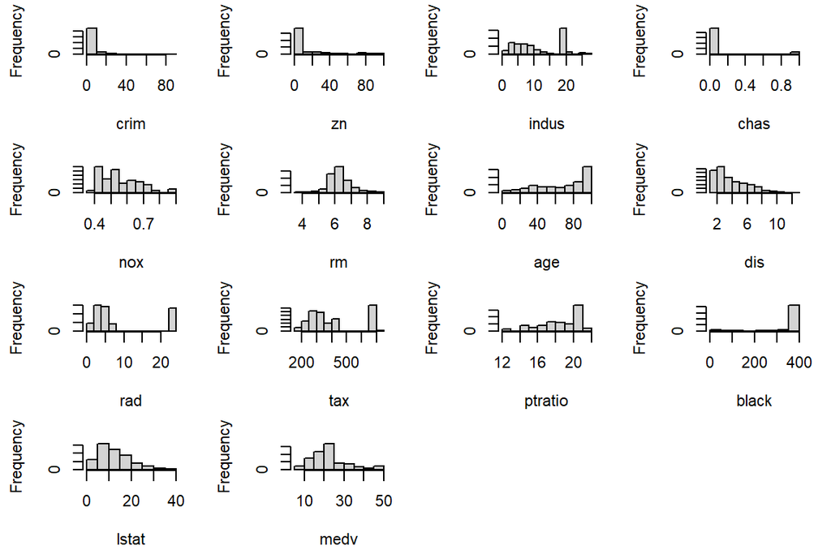

```r
par(mfrow=c(4,4), mai=c(0.6, 0.6, 0.2, 0.2), cex=0.7)
for (i in 1:14) hist(Boston[,i], main="", xlab=names(Boston)[i], cex=0.7)
```

Visualized correlation matrix:

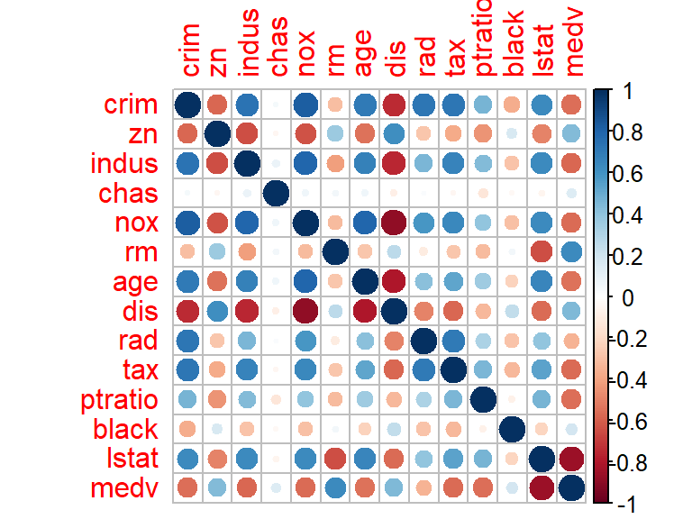

```r
cor_matrix<-cor(Boston, method="spearman")
par(mfrow=c(1,1))
corrplot(cor_matrix, method="circle")
```

```r
# More fancy correlation graph - just for memorize
# corrplot(cor_matrix, method="circle", type="upper", cl.pos = "b", tl.pos = "d" , tl.cex = 0.6)
```

All variables are on very different scale. Most on them are not normally distributed. There are lot of correlations between variables, for example highly negatively are correlated lstat and medv, dis with indus, nox and age. High positive correlation are between nox and indus, age; between indus and tax; between medv and rm.

### 4.2.4 Prepare dataset for discriminant analysis

**Exercise:** Standardize the dataset and print out summaries of the scaled data. How did the variables change? Create a categorical variable of the crime rate in the Boston dataset (from the scaled crime rate). Use the quantiles as the break points in the categorical variable. Drop the old crime rate variable from the dataset. Divide the dataset to train and test sets, so that 80% of the data belongs to the train set.

Center and standardize variables, print out summaries.

```r
boston_scaled <- as.data.frame(scale(Boston))

summary(boston_scaled)
```

```
##       crim                 zn               indus              chas
##  Min.   :-0.419367   Min.   :-0.48724   Min.   :-1.5563   Min.   :-0.2723
##  1st Qu.:-0.410563   1st Qu.:-0.48724   1st Qu.:-0.8668   1st Qu.:-0.2723
##  Median :-0.390280   Median :-0.48724   Median :-0.2109   Median :-0.2723
##  Mean   : 0.000000   Mean   : 0.00000   Mean   : 0.0000   Mean   : 0.0000
##  3rd Qu.: 0.007389   3rd Qu.: 0.04872   3rd Qu.: 1.0150   3rd Qu.:-0.2723
##  Max.   : 9.924110   Max.   : 3.80047   Max.   : 2.4202   Max.   : 3.6648
##       nox                rm               age               dis
##  Min.   :-1.4644   Min.   :-3.8764   Min.   :-2.3331   Min.   :-1.2658
##  1st Qu.:-0.9121   1st Qu.:-0.5681   1st Qu.:-0.8366   1st Qu.:-0.8049
##  Median :-0.1441   Median :-0.1084   Median : 0.3171   Median :-0.2790
##  Mean   : 0.0000   Mean   : 0.0000   Mean   : 0.0000   Mean   : 0.0000
##  3rd Qu.: 0.5981   3rd Qu.: 0.4823   3rd Qu.: 0.9059   3rd Qu.: 0.6617
##  Max.   : 2.7296   Max.   : 3.5515   Max.   : 1.1164   Max.   : 3.9566
##       rad               tax             ptratio            black
##  Min.   :-0.9819   Min.   :-1.3127   Min.   :-2.7047   Min.   :-3.9033
##  1st Qu.:-0.6373   1st Qu.:-0.7668   1st Qu.:-0.4876   1st Qu.: 0.2049
##  Median :-0.5225   Median :-0.4642   Median : 0.2746   Median : 0.3808
##  Mean   : 0.0000   Mean   : 0.0000   Mean   : 0.0000   Mean   : 0.0000
##  3rd Qu.: 1.6596   3rd Qu.: 1.5294   3rd Qu.: 0.8058   3rd Qu.: 0.4332
##  Max.   : 1.6596   Max.   : 1.7964   Max.   : 1.6372   Max.   : 0.4406
##      lstat              medv
##  Min.   :-1.5296   Min.   :-1.9063
##  1st Qu.:-0.7986   1st Qu.:-0.5989
##  Median :-0.1811   Median :-0.1449
##  Mean   : 0.0000   Mean   : 0.0000
##  3rd Qu.: 0.6024   3rd Qu.: 0.2683
##  Max.   : 3.5453   Max.   : 2.9865
```

After centering means of variables are 0.

Use quantiles of variable *crime* as the break points to create a categorical variable. Drop the old crime rate variable from the dataset.

```r
bins <- quantile(boston_scaled$crim)
bins
```

```
##           0%          25%          50%          75%         100%
## -0.419366929 -0.410563278 -0.390280295  0.007389247  9.924109610
```

```r
boston_scaled$crime <- cut(boston_scaled$crim, breaks = bins,
             include.lowest = TRUE,
             label=c("low", "med_low", "med_high", "high"))

table(boston_scaled$crime)
```

```
##
##      low  med_low med_high     high
##      127      126      126      127
```

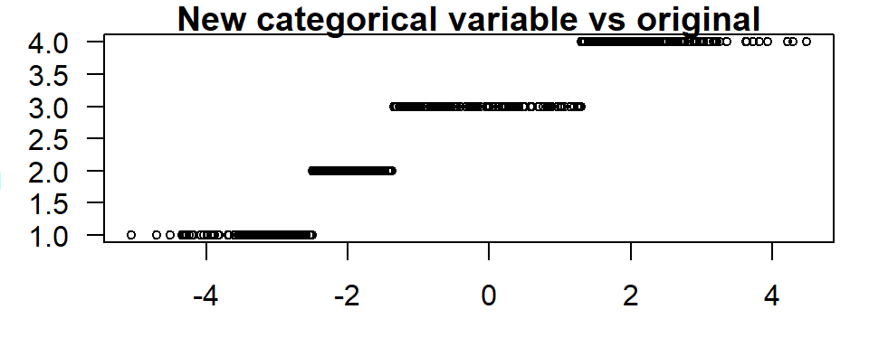

```r
# visualize new vs old crime
par(mai=c(0.6,0.6,0.2,0.2))
plot(log(Boston$crim), boston_scaled$crime, main = "New categorical variable vs original", las=1, cex=0.7)
```

```r
# remove original crim from the dataset
boston_scaled <- dplyr::select(boston_scaled, -crim)
```

Divide dataset to training (80%) and testing (20%) number of rows in the Boston dataset.

```r
# No of rows in dataset
n <- dim(boston_scaled)[1]

# Choose randomly 80% of the rows
ind <- sample(n,  size = n * 0.8)

# Create train set
train <- boston_scaled[ind,]

# Create test set
test <- boston_scaled[-ind,]
```

### 4.2.5 Fit the linear discriminant analysis

**Exercise:** Fit the linear discriminant analysis on the train set. Use the categorical crime rate as the target variable and all the other variables in the dataset as predictor variables. Draw the LDA (bi)plot.

Fit linear discriminant analysis and print the results and make plot.

```r
lda.fit <- lda(crime ~ ., data = train)
lda.fit
```

```
## Call:
## lda(crime ~ ., data = train)
##
## Prior probabilities of groups:
##       low   med_low  med_high      high
## 0.2475248 0.2475248 0.2326733 0.2722772
##
## Group means:
##                   zn      indus         chas        nox         rm        age
## low       0.91398463 -0.8893097 -0.154216061 -0.8587336  0.4753166 -0.8367621
## med_low  -0.07733476 -0.2960458  0.003267949 -0.5736744 -0.1008578 -0.3807934
## med_high -0.38506488  0.2488285  0.230279473  0.3797718  0.1731424  0.4199782
## high     -0.48724019  1.0169558 -0.021786325  1.0691952 -0.3971228  0.8077384
##                 dis        rad        tax     ptratio       black         lstat
## low       0.8380044 -0.6821213 -0.7492543 -0.40626131  0.38263235 -0.7866426066
## med_low   0.3406634 -0.5488991 -0.5084171 -0.05659893  0.31479721 -0.1742966699
## med_high -0.3856829 -0.3722063 -0.2658858 -0.36913198  0.08341583  0.0008075195
## high     -0.8585184  1.6397657  1.5152267  0.78268316 -0.76124799  0.8798450564
##                 medv
## low       0.56954816
## med_low   0.03481462
## med_high  0.21088531
## high     -0.69182715
##
## Coefficients of linear discriminants:
##                 LD1         LD2         LD3
## zn       0.05872659  0.84970392 -0.86248467
## indus    0.02595636 -0.29096170  0.21570362
## chas    -0.06888021 -0.08422637  0.18774348
## nox      0.42192976 -0.58215900 -1.31356851
## rm      -0.06800021 -0.15304397 -0.16905082
## age      0.25053340 -0.30460117 -0.26198077
## dis     -0.06160380 -0.34681389  0.03596451
## rad      2.99901719  0.95153143 -0.01211452
## tax      0.01558759 -0.19080890  0.44292133
## ptratio  0.06683379  0.20910016 -0.15901637
## black   -0.12287685 -0.01066390  0.11541196
## lstat    0.22359910 -0.25899800  0.35623826
## medv     0.19143078 -0.32606600 -0.28411826
##
## Proportion of trace:
##    LD1    LD2    LD3
## 0.9513 0.0366 0.0121
```

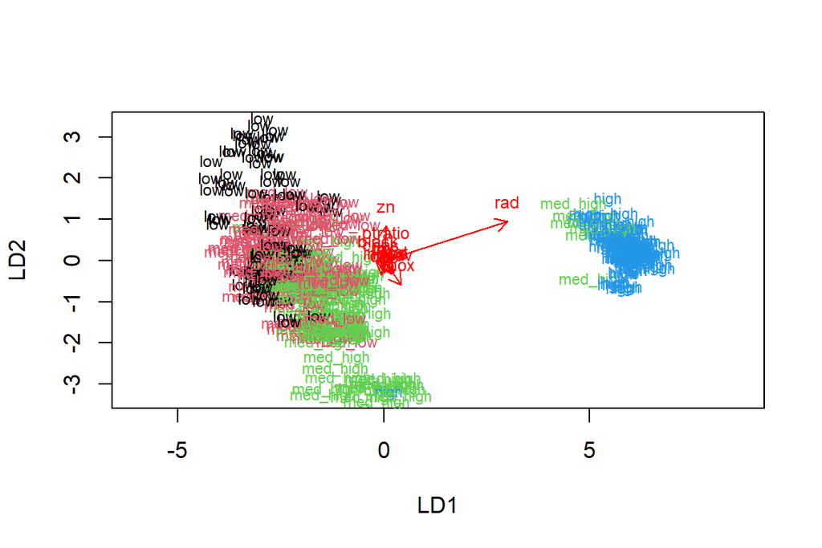

```r
# function for lda biplot arrows
lda.arrows <- function(x, myscale = 1, arrow_heads = 0.1, color = "red", tex = 0.75, choices = c(1,2)){
  heads <- coef(x)
  arrows(x0 = 0, y0 = 0,
         x1 = myscale * heads[,choices[1]],
         y1 = myscale * heads[,choices[2]], col=color, length = arrow_heads)
  text(myscale * heads[,choices], labels = row.names(heads),
       cex = tex, col=color, pos=3)
}
# target classes as numeric
classes <- as.numeric(train$crime)
# plot the lda results
plot(lda.fit , dimen = 2, col=classes, pch=classes)
lda.arrows(lda.fit, myscale = 1)
```

The output presents distribution of target variable, means on descriptive variables in target variable groups and coefficients of linear discriminants (needed to make latent variables describing target variable groups).

### 4.2.6 Testing model on test data

**Exercise:** Save the crime categories from the test set and then remove the categorical crime variable from the test dataset. Then predict the classes with the LDA model on the test data. Cross tabulate the results with the crime categories from the test set. Comment on the results.

```r
# save the correct classes from test data
test$correct_classes <- test$crime

# remove the crime variable from test data
test <- dplyr::select(test, -crime)

# predict classes with test data
lda.pred <- predict(lda.fit, newdata = test)

# cross tabulate the results
a = table(correct = test$correct_classes, predicted = lda.pred$class)
a
```

```
##           predicted
## correct    low med_low med_high high
##   low       16      11        0    0
##   med_low    2      18        6    0
##   med_high   0      16       16    0
##   high       0       0        0   17
```

```r
# correct predictions
sum(a[1,1]+a[2,2]+a[3,3]+a[4,4]) / sum(a)
```

```
## [1] 0.6568627
```

### 4.2.7 Cluster analysis

**Exercise:** Reload the Boston dataset and standardize the dataset (we did not do this in the Datacamp exercises, but you should scale the variables to get comparable distances). Calculate the distances between the observations. Run k-means algorithm on the dataset. Investigate what is the optimal number of clusters and run the algorithm again. Visualize the clusters (for example with the pairs() or ggpairs() functions, where the clusters are separated with colors) and interpret the results.

```r
# Euclidean distance matrix
dist_eu <- dist(boston_scaled)

# Look at the summary of the distances
summary(dist_eu)
```

```
##    Min. 1st Qu.  Median    Mean 3rd Qu.    Max.
##  0.1394  3.5267  4.9081  4.9394  6.2421 13.0045
```

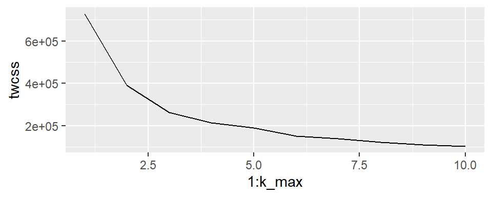

```r
# Determine the number of clusters
set.seed(123)
k_max <- 10

# calculate the total within sum of squares
twcss <- sapply(1:k_max, function(k){kmeans(dist_eu, k)$tot.withinss})

# visualize the results
qplot(x = 1:k_max, y = twcss, geom = 'line')
```

According to the last plot 2 cluster is enough.

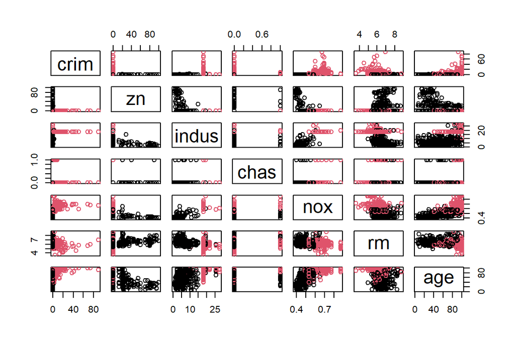

```r
# k-means clustering
km <-kmeans(dist_eu, centers = 2)

# plot the Boston dataset with clusters
pairs(Boston[1:7], col = km$cluster)
```

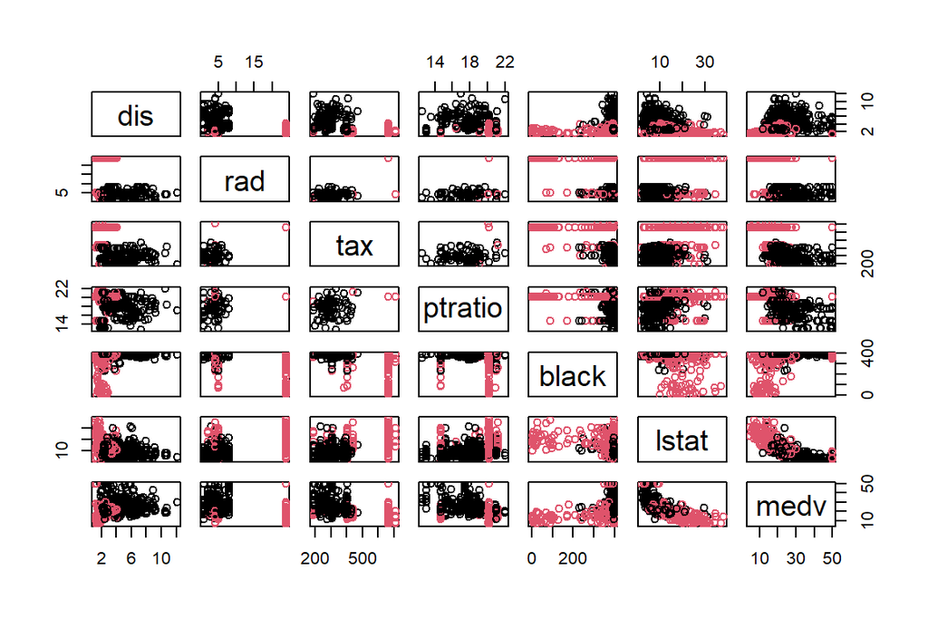

```r
pairs(Boston[8:14], col = km$cluster)
```

I made cluster plots by two graphs. I think that clusters are more clearly separated by variables medv, lstat, age, rm, nox and crime.

### Bonus

**Exercise:** Perform k-means on the original Boston data with some reasonable number of clusters (> 2). Remember to standardize the dataset. Then perform LDA using the clusters as target classes. Include all the variables in the Boston data in the LDA model. Visualize the results with a biplot (include arrows representing the relationships of the original variables to the LDA solution). Interpret the results. Which variables are the most influencial linear separators for the clusters?

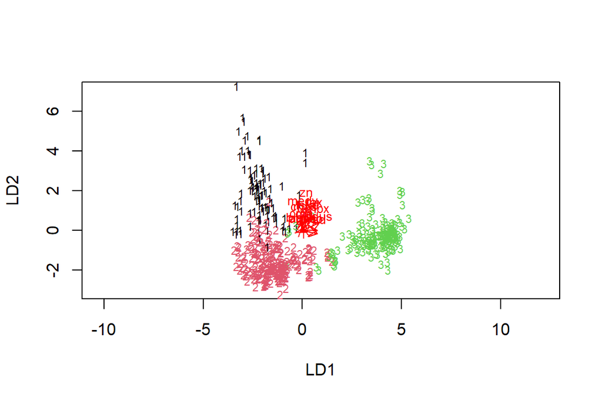

```r
boston_scaled = as.data.frame(scale(Boston))
dist_eu = dist(boston_scaled)
boston_scaled$target<-kmeans(dist_eu, centers = 3)$cluster
lda.fit <- lda(target  ~ ., data = boston_scaled)
classes <- as.numeric(boston_scaled$target)
plot(lda.fit , dimen = 2, col=classes, pch=classes)
lda.arrows(lda.fit, myscale = 1)
```

```r
lda.pred <- predict(lda.fit, newdata = boston_scaled)
a = table(correct = boston_scaled$target, predicted = lda.pred$class)
a
```

```
##        predicted
## correct   1   2   3
##       1  88  17   0
##       2   5 221   4
##       3   0   7 164
```

```r
sum(a[1,1]+a[2,2]+a[3,3]) / sum(a)
```

```
## [1] 0.9347826
```

I did not separate dataset here as trainig and and testing, so the rate of correct answers is high - over 90%.

# Chapter 5 – Dimensionality reduction techniques

```
## [1] "Fri Dec 04 03:13:52 2020"
```

**Useful links to PCA**  
http://factominer.free.fr/  
https://setosa.io/ev/principal-component-analysis/  
https://arxiv.org/pdf/1404.1100.pdf  
https://www.fbbva.es/microsite/multivariate-statistics/biplots.html  
https://youtu.be/aiqGyLGrQ48?list=PLnZgp6epRBbTsZEFXi_p6W48HhNyqwxIu

## 5.1 Data wrangling

Comment: Continue data wrangling from last week. Change non-numeric data to numeric data, remove rows with NA-s, keep only country-based data, keep selected variables

```r
library(stringr); library(dplyr); library(tidyr)
```

### 5.1.0 Read the data

```r
human <- read.csv("http://s3.amazonaws.com/assets.datacamp.com/production/course_2218/datasets/human1.txt", stringsAsFactors = F)

str(human)
summary(human)
dim(human)
```

### 5.1.1 Mutate data

Change 12,000-style variable to numeric 12000-style

```r
human = mutate(human, GNI=as.numeric(str_replace(human$GNI, pattern=",", replace ="")))
summary(human$GNI)
```

### 5.1.2 Keep selected variables

```r
# Columns to keep
keep <- c("Country", "Edu2.FM", "Labo.FM", "Edu.Exp", "Life.Exp", "GNI", "Mat.Mor", "Ado.Birth", "Parli.F")

human <- select(human, one_of(keep))
names(human)
dim(human)
```

### 5.1.3 Remove all rows with missing values

```r
human <- filter(human, complete.cases(human))
dim(human)
```

### 5.1.4 Remove all rows with region data

```r
# Last rows on human data
tail(human,n=10)

# Choose everything until the last 7 observations
human <- human[1:(nrow(human) - 7), ]

dim(human)
```

### 5.1.5 Adapt row names from variable country and save the data

```r
rownames(human) <- human$Country
human <- dplyr::select(human, -Country)

dim(human)

write.csv(human, file = (paste0(getwd(), "/data/human.csv")), row.names=T)
```

## 5.2 Data analysis

Read data

```r
human = read.csv(file = (paste0(getwd(), "/data/human.csv")), row.names=1)
```

Data has 155 rows and 8 variables.

Today’s libraries

```r
library(ggplot2); library(GGally)
library(tidyr); library(dplyr)
library(corrplot); library(MASS)
```

### 5.2.1 Overview of data

```r
names(human)
```

```
## [1] "Edu2.FM"   "Labo.FM"   "Edu.Exp"   "Life.Exp"  "GNI"       "Mat.Mor"
## [7] "Ado.Birth" "Parli.F"
```

Explabnation of variables in dataset:

| variables | explanation |
| --- | --- |
| Edu.Exp | Expected years of schooling |
| Life.Exp | Life expectancy at birth |
| GNI | Gross National Income per capita |
| Mat.Mor | Maternal mortality ratio |
| Ado.Birth | Adolescent birth rate |
| Parli.F | Percetange of female representatives in parliament |
| Edu2.FM | Ratio of proportion of females and males with at least secondary education (educational inequality between females and males) |
| Labo.FM | Ratio of proportion of females and males in the labour force (labour force inequality between females and males) |

```r
str(human)
```

```
## 'data.frame':    155 obs. of  8 variables:
##  $ Edu2.FM  : num  1.007 0.997 0.983 0.989 0.969 ...
##  $ Labo.FM  : num  0.891 0.819 0.825 0.884 0.829 ...
##  $ Edu.Exp  : num  17.5 20.2 15.8 18.7 17.9 16.5 18.6 16.5 15.9 19.2 ...
##  $ Life.Exp : num  81.6 82.4 83 80.2 81.6 80.9 80.9 79.1 82 81.8 ...
##  $ GNI      : int  64992 42261 56431 44025 45435 43919 39568 52947 42155 32689 ...
##  $ Mat.Mor  : int  4 6 6 5 6 7 9 28 11 8 ...
##  $ Ado.Birth: num  7.8 12.1 1.9 5.1 6.2 3.8 8.2 31 14.5 25.3 ...
##  $ Parli.F  : num  39.6 30.5 28.5 38 36.9 36.9 19.9 19.4 28.2 31.4 ...
```

```r
summary(human)
```

```
##     Edu2.FM          Labo.FM          Edu.Exp         Life.Exp
##  Min.   :0.1717   Min.   :0.1857   Min.   : 5.40   Min.   :49.00
##  1st Qu.:0.7264   1st Qu.:0.5984   1st Qu.:11.25   1st Qu.:66.30
##  Median :0.9375   Median :0.7535   Median :13.50   Median :74.20
##  Mean   :0.8529   Mean   :0.7074   Mean   :13.18   Mean   :71.65
##  3rd Qu.:0.9968   3rd Qu.:0.8535   3rd Qu.:15.20   3rd Qu.:77.25
##  Max.   :1.4967   Max.   :1.0380   Max.   :20.20   Max.   :83.50
##       GNI            Mat.Mor         Ado.Birth         Parli.F
##  Min.   :   581   Min.   :   1.0   Min.   :  0.60   Min.   : 0.00
##  1st Qu.:  4198   1st Qu.:  11.5   1st Qu.: 12.65   1st Qu.:12.40
##  Median : 12040   Median :  49.0   Median : 33.60   Median :19.30
##  Mean   : 17628   Mean   : 149.1   Mean   : 47.16   Mean   :20.91
##  3rd Qu.: 24512   3rd Qu.: 190.0   3rd Qu.: 71.95   3rd Qu.:27.95
##  Max.   :123124   Max.   :1100.0   Max.   :204.80   Max.   :57.50
```

All variables are numeric. Values are on different scale, and results probably depends on history and development of county (poorer countries have lower life expectancy, less educated females, higher maternal mortality etc).

Visualize the human variables:

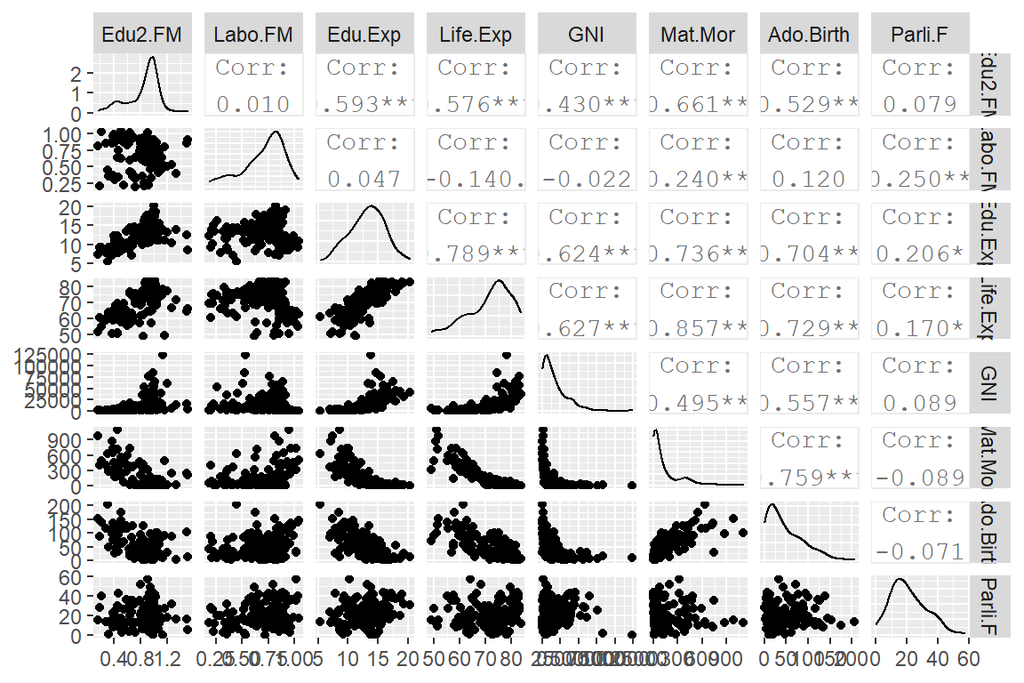

```r
ggpairs(human)
```

Variables are not distributed normally.

High positive correlations (r>0.7) are between:

- life expectancy and expected years of schooling
- maternal mortality ratio and adolescent birth rate

High negative correlatios (r<-0.7) are between:

- maternal mortality ratio and expected years of schooling
- maternal mortality ratio and life expectancy
- life expectancy and adolescent birth rate

### 5.2.2 PCA, not standardized data

*A biplot is a way of visualizing the connections between two representations of the same data.* *First, a simple scatter plot is drawn where the observations are represented by two principal components (PC’s). Then, arrows are drawn to visualize the connections between the original variables and the PC’s. The following connections hold: * The angle between the arrows can be interpret as the correlation between the variables. * The angle between a variable and a PC axis can be interpret as the correlation between the two. * The length of the arrows are proportional to the standard deviations of the variables*

```r
pca_human <- prcomp(human)
summary(pca_human)
```

```
## Importance of components:
##                              PC1      PC2   PC3   PC4   PC5   PC6    PC7    PC8
## Standard deviation     1.854e+04 185.5219 25.19 11.45 3.766 1.566 0.1912 0.1591
## Proportion of Variance 9.999e-01   0.0001  0.00  0.00 0.000 0.000 0.0000 0.0000
## Cumulative Proportion  9.999e-01   1.0000  1.00  1.00 1.000 1.000 1.0000 1.0000
```

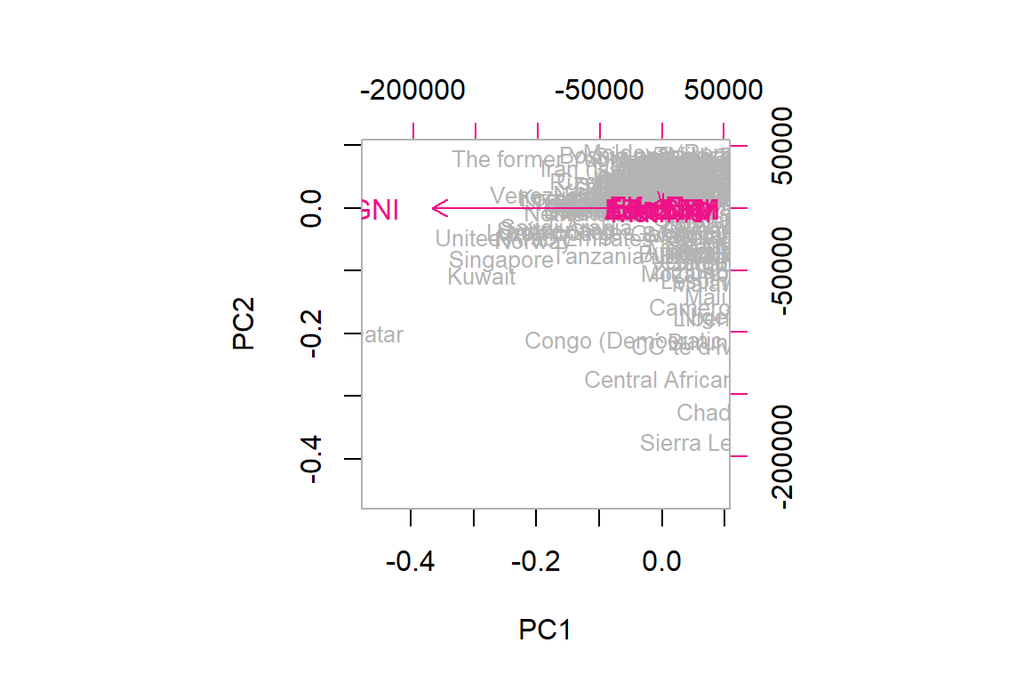

```r
biplot(pca_human, choices = 1:2, cex=c(0.8, 1),col = c("grey70", "deeppink2"))
```

### 5.2.3 PCA, standardized data

```r
human_std <- scale(human)
pca_human_std <- prcomp(human_std)
summary(pca_human_std)
```

```
## Importance of components:
##                           PC1    PC2     PC3     PC4     PC5     PC6     PC7
## Standard deviation     2.0708 1.1397 0.87505 0.77886 0.66196 0.53631 0.45900
## Proportion of Variance 0.5361 0.1624 0.09571 0.07583 0.05477 0.03595 0.02634
## Cumulative Proportion  0.5361 0.6984 0.79413 0.86996 0.92473 0.96069 0.98702
##                            PC8
## Standard deviation     0.32224
## Proportion of Variance 0.01298
## Cumulative Proportion  1.00000
```

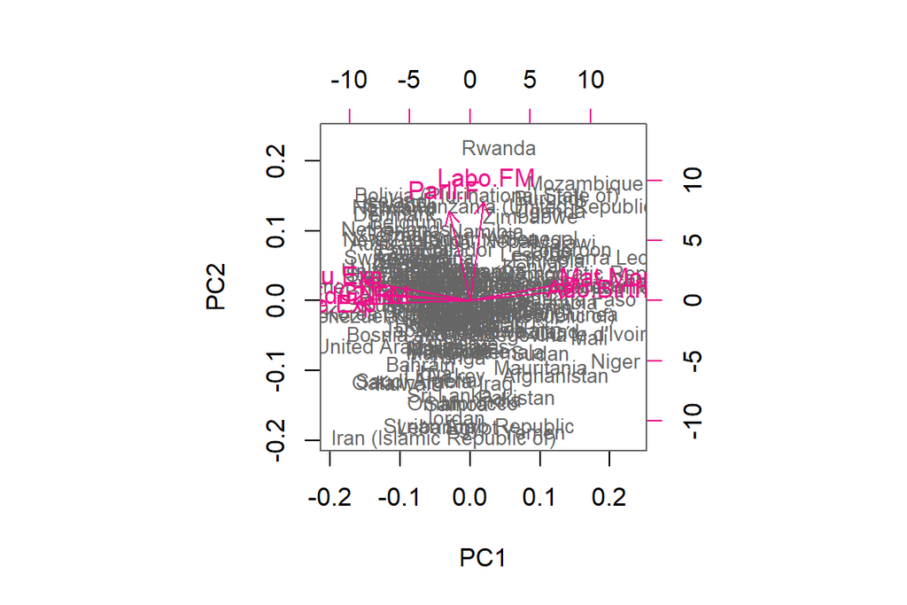

```r
biplot(pca_human_std, choices = 1:2, cex=c(0.8, 1),col = c("grey40", "deeppink2"))
```

On the first PCA analysis is key-variable Gross National Income per capita (GNI). As it has high values (on really different scale compared others) and huge variability, it holds 99% of data variability and principal component 1 is highly tilted to GNI.

The second PCA analysis is done on scaled data (means are around zero and standard deviation should be 1). First PC holds 53% of variability, second 16% and third 9%. It seems that preferred number of principal components is two.

By the plot:

- percetange of female representatives in parliament (Parli.F) and labour force inequality between females and males (Labo.FM) is going to same PC (PC2). Arrows are on the same direction and angle between them is small, it means they positively correlated.
- maternal mortality ratio (Mat.Mor) is related with adolescent birth rate (Ado.Birth) and it belongs to the first principal component
- Arrows to expected years of schooling (Edu2.FM), Life expectancy at birth (Life.Exp), Gross National Income per capita)(GNI), educational inequality between females and males (Edu2.FM) are near to each other and belongs to PC1 (as birth rate and mortality ratio) but on other direction.